# Incidenti stradali in Italia

26 Giugno 2023

## Introduzione e domande

Ho scelto di fare questa analisi per analizzare gli incidenti stradali in Italia.  
Variabili che possono incidere su un incidente stradale:

- Popolazione dell’area geografica?
- Parco veicolare dell’area geografica?
- Ora del giorno? Giorno della settimana? Mese dell’anno?
- Tipo di strada percorsa?

## Raccolta dati e dataset

Ho analizzato i dataset disponibili su internet di varie organizzazioni (ISTAT, MIT, ACI, OECD…). Alla fine ho deciso di prendere i dati dall’ISTAT dove erano più completi e affidabili.

Ho estrapolato vari dataset riguardanti il parco veicolare, gli incidenti e la popolazione di dimensione molto variabile (da decine di righe a milioni).  
Quindi ho escluso le cose inutili e li ho adattati alle mie necessità.

## Rapporto incidenti-popolazione per regione

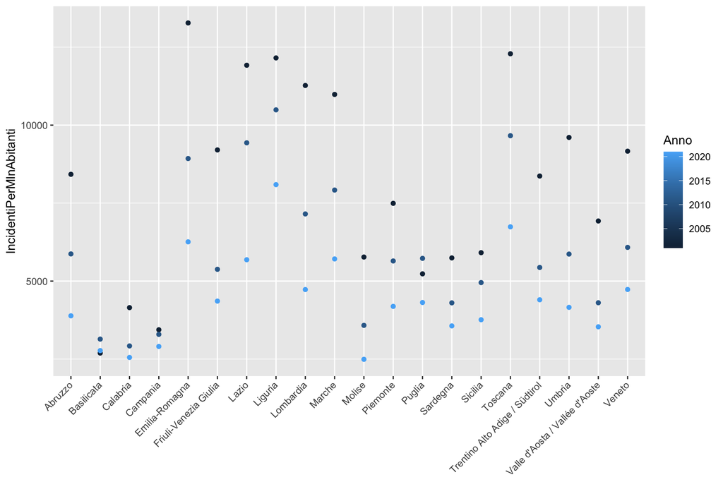

Gli incidenti sono rapportati alla popolazione dell’area geografica?  
Sì, come possiamo vedere da questi due grafici gli incidenti sono abbastanza collegabili alla popolazione.

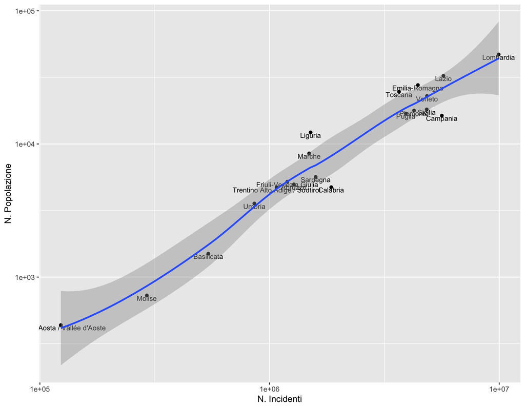

## Mappa incidenti in rapporto alla popolazione per provincia nel 2021

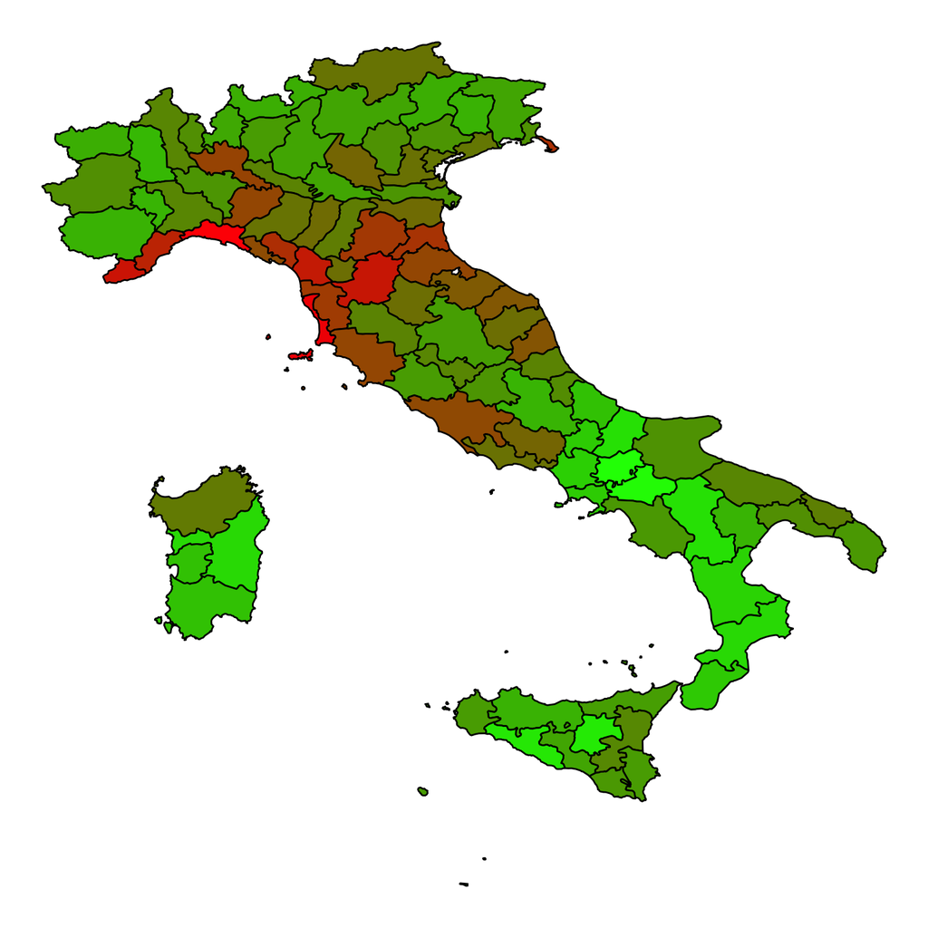

## Incidenti in rapporto al parco veicolare per regione nel 2021

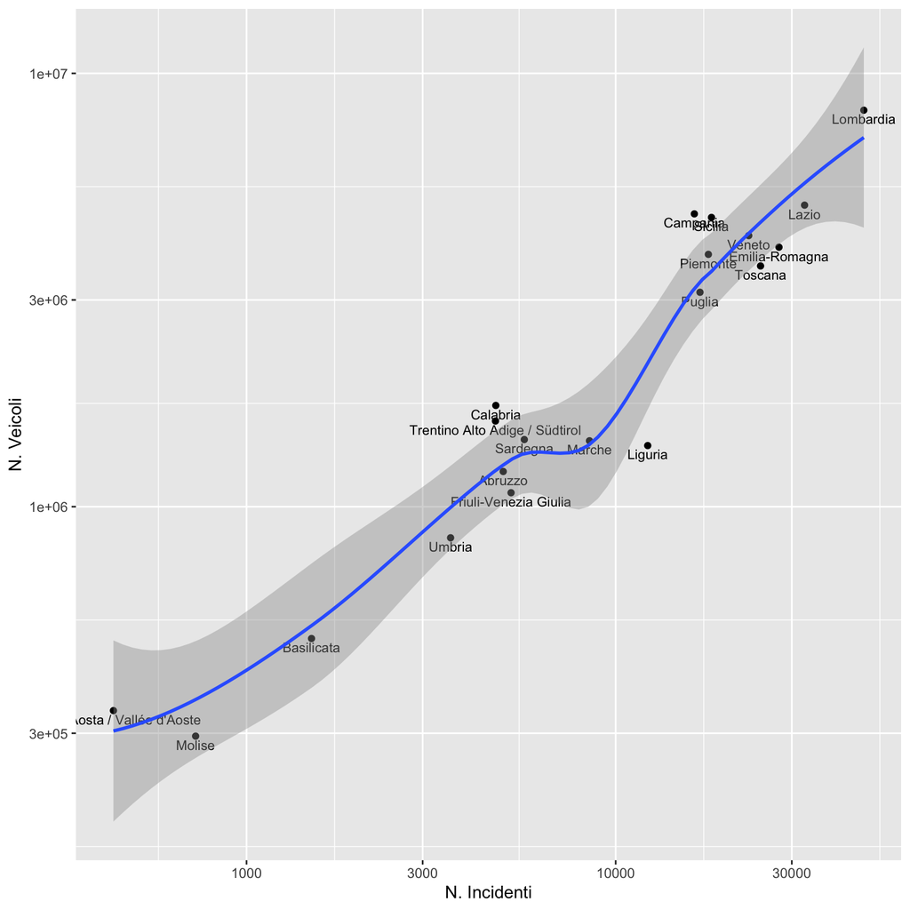

Gli incidenti sono rapportati al parco veicolare?  
Sì, come possiamo vedere da questo grafico gli incidenti sono abbastanza collegabili al parco veicolare.

## Mappa incidenti in rapporto al parco veicolare per provincia nel 2021

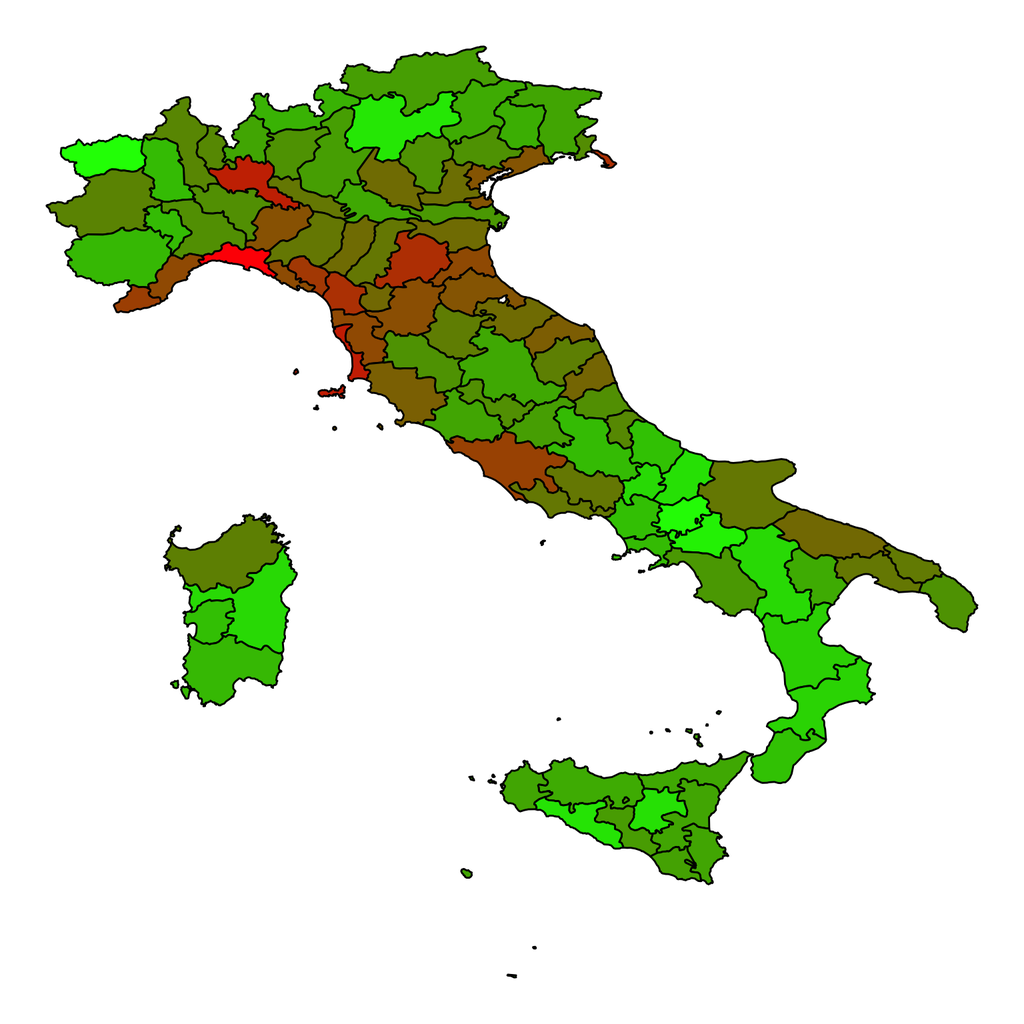

Possiamo vedere che i dati degli incidenti al Sud (soprattutto in Calabria e Campania) sembrano un po’ ottimisti, probabilmente ciò è dato dalle ridotte segnalazioni alle Forze dell’Ordine.  
Generalmente le zone costiere sono più incidentate dell’entroterra.

## Quantità di incidenti per fascia oraria

### Somma dei valori di tutti gli anni dal 2001 al 2021

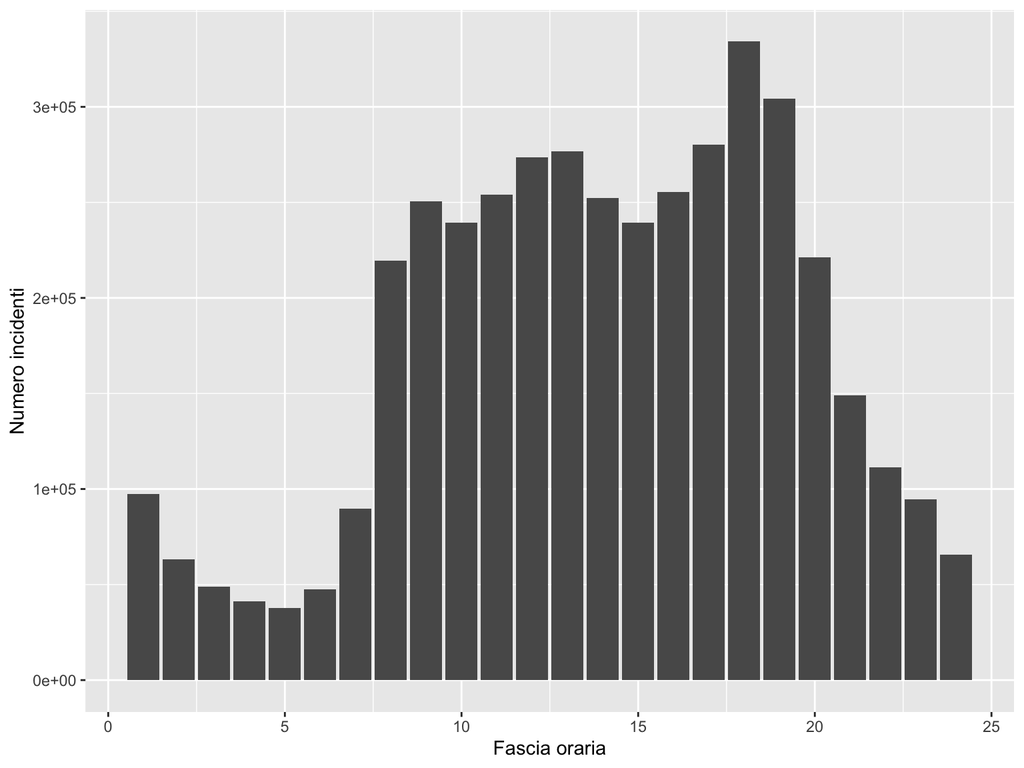

Ci sono più possibilità di fare un incidente ad una certa ora del giorno?  
Sì l’ora “maledetta” sono le 18, questo perché la gente ritorna dalla giornata lavorativa (stress e stanchezza) o va a fare commissioni, in questa fascia oraria le strade sono molto trafficate e pericolose.

### Negli anni 2001, 2011 e 2021

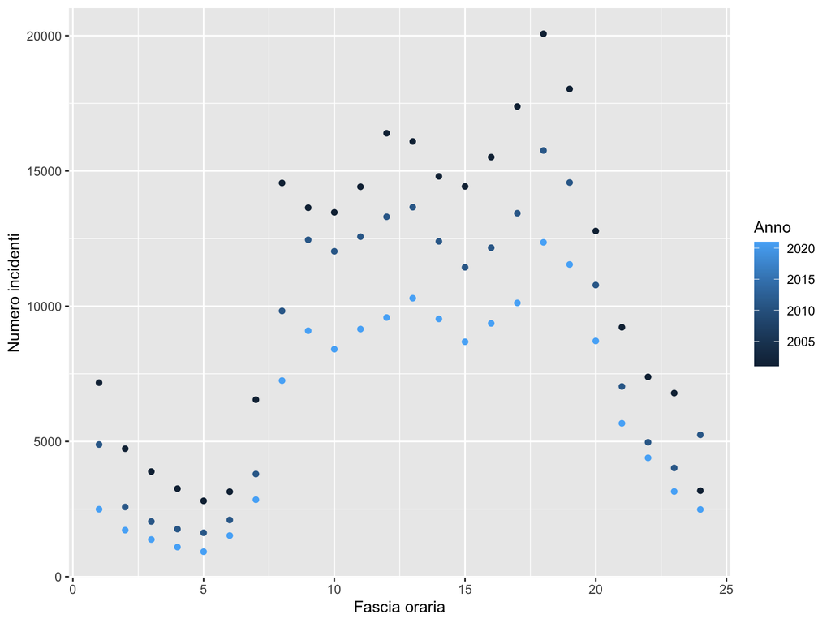

## Quantità di incidenti per giorno della settimana

### Somma dei valori di tutti gli anni dal 2001 al 2021

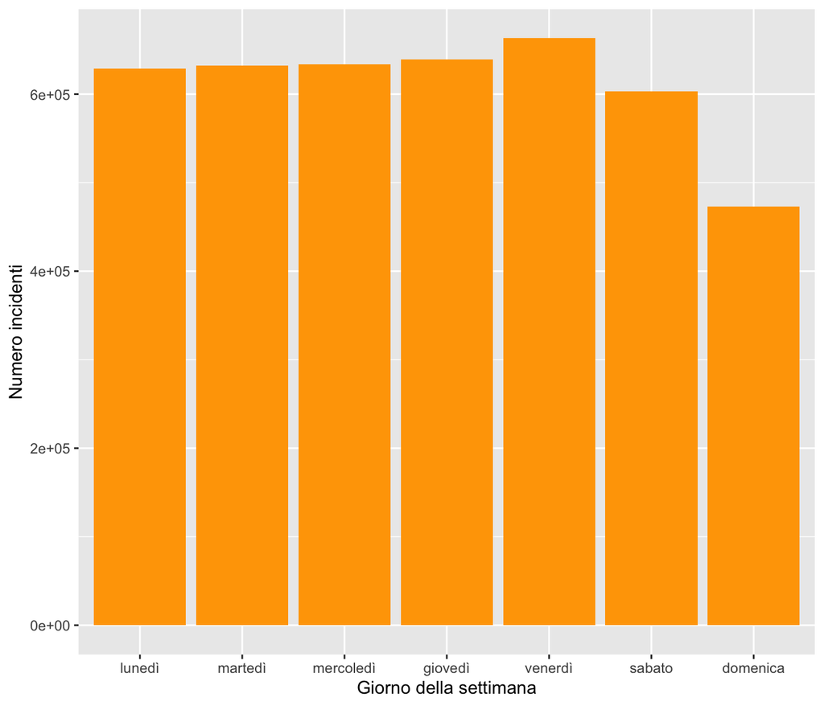

Ci sono più possibilità di fare incidenti certi giorni della settimana?  
Sì il giorno più atteso della settimana (venerdì) è anche quello in cui accadono più incidenti, anche questo dovuto all’alto traffico e alla stanchezza lavorativa.  
La domenica è il giorno più tranquillo, molti stanno a casa.

## Quantità di incidenti per mese

### Somma dei valori di tutti gli anni dal 2001 al 2021

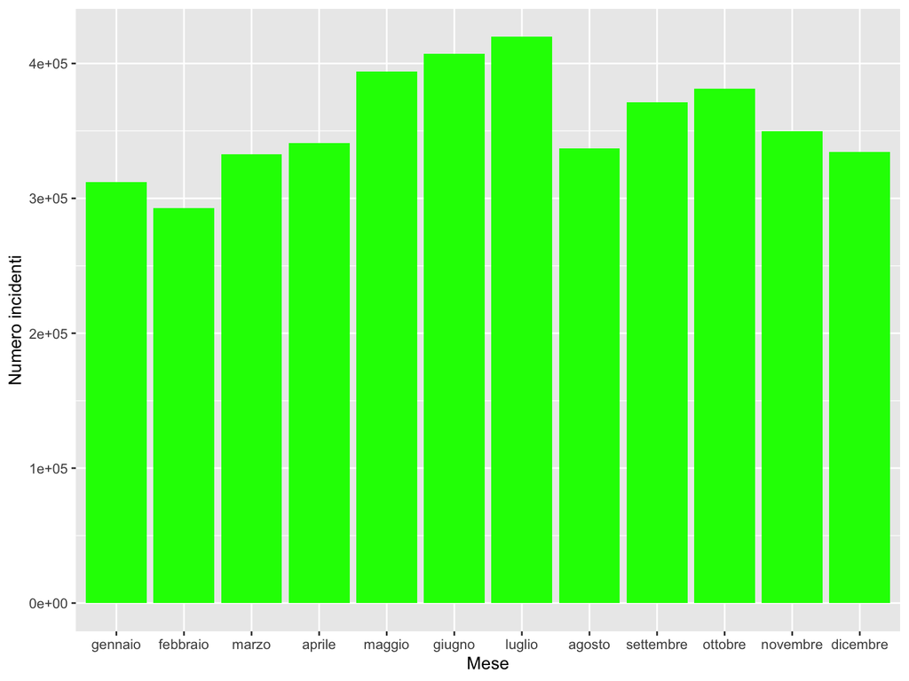

Ci sono più possibilità di fare incidenti certi mesi dell’anno?  
Sì, le possibilità sono un po’ più alte nei mesi estivi/autunnali. Agosto è l’eccezione alla regola infatti gli incidenti sono più ridotti poiché molti sono in vacanza.

### Negli anni 2001, 2011 e 2021

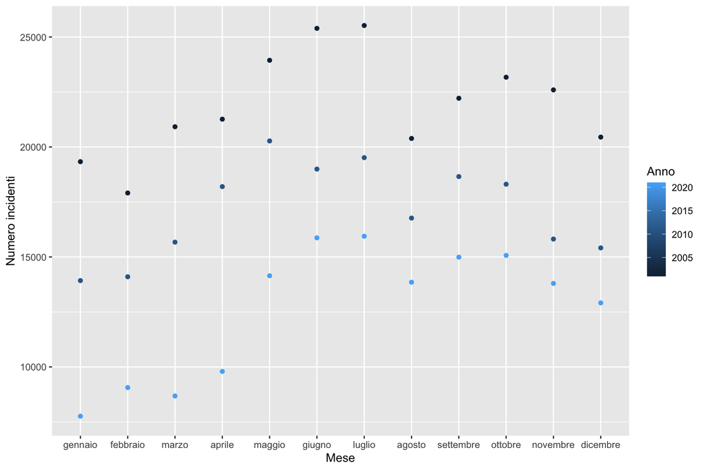

## Percentuale di incidenti per varie caratteristiche dal 2001 al 2021

### Tipo di strada in cui è accaduto l’incidente

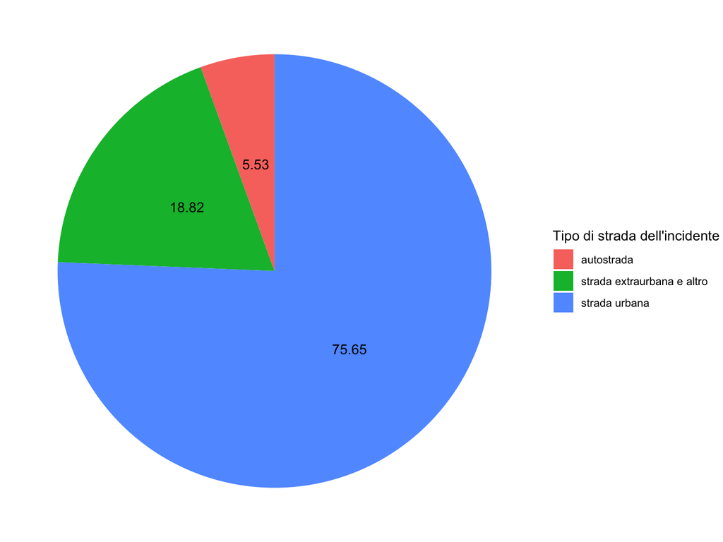

Il tipo di strada percorsa incide? Sì, come atteso le strade urbane sono molto pericolose (imprudenza, incroci pericolosi, pedoni…).

### Tipo di intersezione in cui è accaduto l’incidente

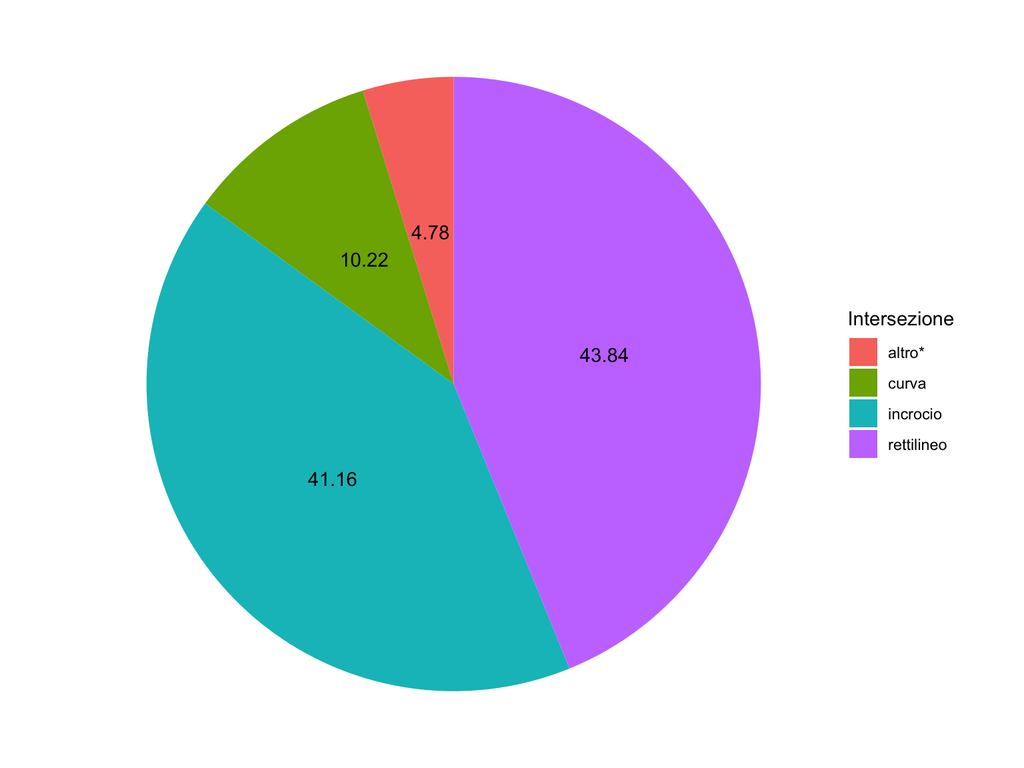

*Altro è un dato cumulativo di: rotatoria, dosso, pendenza, strettoia, galleria, passaggio a livello…  
Stupisce un po’ l’alta percentuale di incidenti sui rettilinei, oltre il 40% (scarsa attenzione alla guida e imprudenza).  
Come già noto anche gli incroci sono molto pericolosi.

### Natura dell’incidente

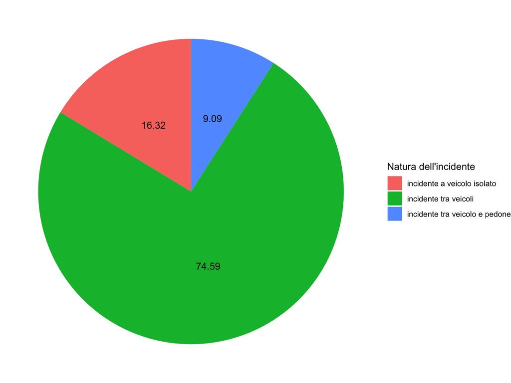

“Pochi” incidenti tra veicoli e pedoni (<10%) ma non vanno sottovalutati perché spesso sono fatali.

## Conclusioni

Sebbene nell’analisi degli incidenti non venissero considerati i turisti (che contribuiscono agli incidenti), il meteo e nemmeno gli incidenti “leggeri” (senza il coinvolgimento delle Forze dell’Ordine), si è comunque riusciti ad ottenere dei dati per lo più affidabili in tutti i grafici.

Questo progetto mi è stato molto utile per ampliare le mie conoscenze sulla Data Science e per imparare ad usare R. Inoltre mi ha permesso di scoprire molti dati interessanti sull’incidentalità stradale in Italia.

Sviluppi futuri (avendo più tempo):

- analisi più dettagliata dei veicoli;
- mortalità incidenti stradali.